# Lab 6: Introduction to Inference

Johanna Ravenhurst

2022-11-05

```r
require(here)
require(palmerpenguins)
```

#Resampling with replacement - Monte Carlo (walkthrough code - not printed to html)

#Bootstrap Resampling

#T-tests

#Two-sample resampling

#Difference of means

#Calculate difference in means using aggregate function

#Sample sizes #Use Table function to show the number of individuals of each species

#Simulation Function

#Resampling experiment

#Lab Questions #Q1 - Sample Standard Error Function

```r
#Write function for calculating standard error

rm(list = ls())

sse_mean = function(x)
{
  sse = sd(x, na.rm=TRUE)/sqrt(length(!is.na(x)))
  return (sse)
}

sse_mean(penguins$body_mass_g)
```

```
## [1] 43.23849
```

```r
sse_mean(mtcars$mpg)
```

```
## [1] 1.065424
```

#Q2-3 Two Group Resampling

```r
#Q2: Show R code for function
two_group_resample_diff = function(x, n_1, n_2)
{

  dat_1 = sample(x, n_1, replace = TRUE)
  dat_2 = sample(x, n_2, replace = TRUE)

  difference_in_means=
  mean(dat_1, na.rm = TRUE) - mean(dat_2, na.rm = TRUE)

  return(difference_in_means)
}

#The function needed to sample with replacement because otherwise we just end up with our original sample again.

#Q3: This function performs Monte Carlo resampling and simulates a null hypothesis. It samples without preserving the structure of the data and potential associations between the variables in each row.
```

#Q4-5: Resampled Flipper Lengths

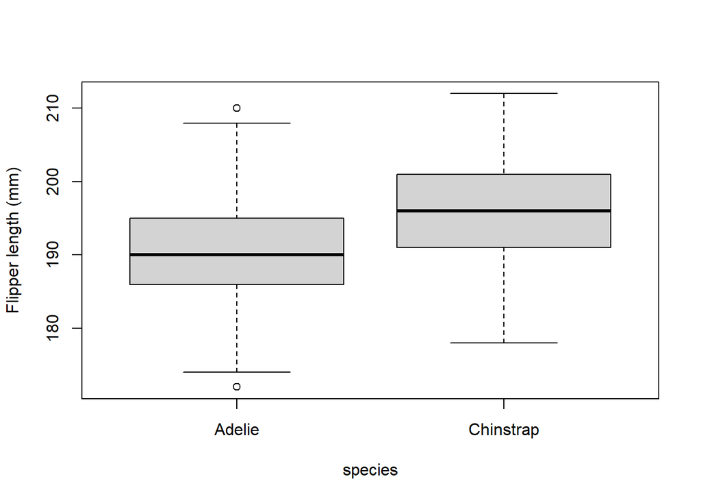

```r
#Use your two_group_resample_diff() function along with a loop to generate 2000 resampled differences of means for flipper length between the two penguin species (Adelie and Chinstrap).

#Code from walkthrough needed for this question
dat_pen = droplevels(subset(penguins, species != "Gentoo"))
{
  boxplot(
    flipper_length_mm ~ species, data = dat_pen,
    ylab = "Flipper length (mm)")
}
```

```r
agg_means = aggregate(
  flipper_length_mm ~ species,
  data = dat_pen,
  FUN = "mean",
  na.rm = TRUE)
diff_observed = diff(agg_means[, 2])

agg_means
```

```
##     species flipper_length_mm
## 1    Adelie          189.9536
## 2 Chinstrap          195.8235
```

```r
diff_observed
```

```
## [1] 5.869887
```

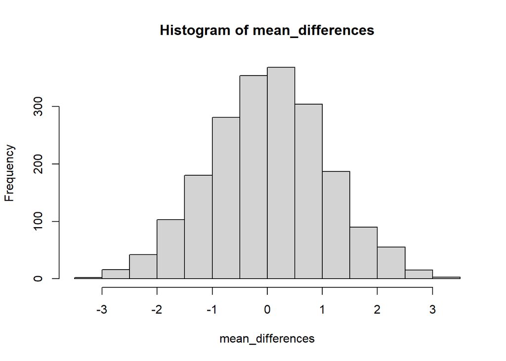

```r
#my code

n = 2000
mean_differences = c()
for (i in 1:n)
{
  mean_differences = c(
    mean_differences,
    two_group_resample_diff(dat_pen$flipper_length_mm, 68, 152)
  )
}

#Q4: Histogram of resampled differences of means
hist(mean_differences)
```

```r
#Q5: How many resampled differences of means had a magnitude greater than 5.8? (which is the difference we observed in the original data)


sum(abs(mean_differences) >= diff_observed)
```

```
## [1] 0
```

```r
#Answer = 0
```

#Q6 - Resampling and p-values

#Q6 (2 pts.): Given a p value of less than 1 per 10 million, how many simulations do you think you would have to do to see a difference in mean flipper length equal to or greater than 5.8 mm?

#I think I would have to run at least 10 million simulations to see a difference in mean flipper length equal to or greater than 5.8 mm.